# Introduction to data science in R, Lesson 7: Introduction to ggplot

## Geometries

A **geometry** plot element provides a visible representation of observations. They are called using the function `geom_[geometry]`. Geometries that we will use in this workshop include:

- `geom_bar`: Bars for bar plots
- `geom_histogram`: Histogram plot for observing distributions
- `geom_violin`: Violin (or bean) plot for observing distributions
- `geom_density`: Density plot for observing distributions
- `geom_point`: Point plot for observing raw data

We will start with a bar plot in which we count the number of observations for each species. Note that plot elements are connected using `+` and each element start on a new line:

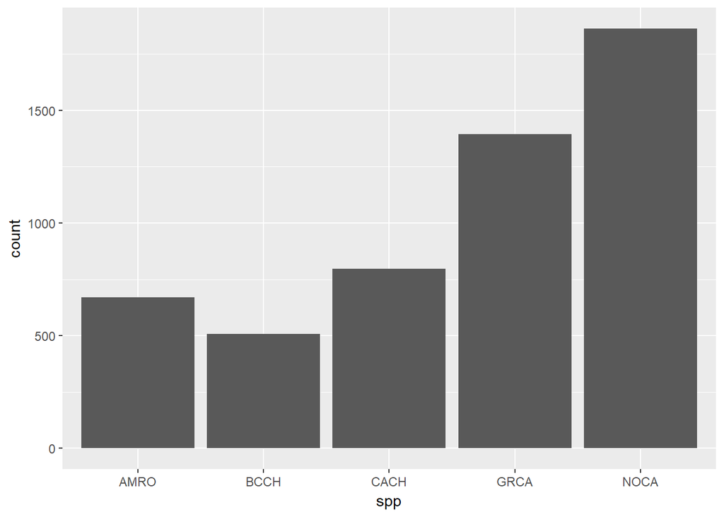

```r
ggplot(birdMeasures, aes(x = spp)) +
  geom_bar()
```

Note that `birdMeasures` is the data frame and the first argument of `ggplot`. This allows us to use a pipe (and we should):

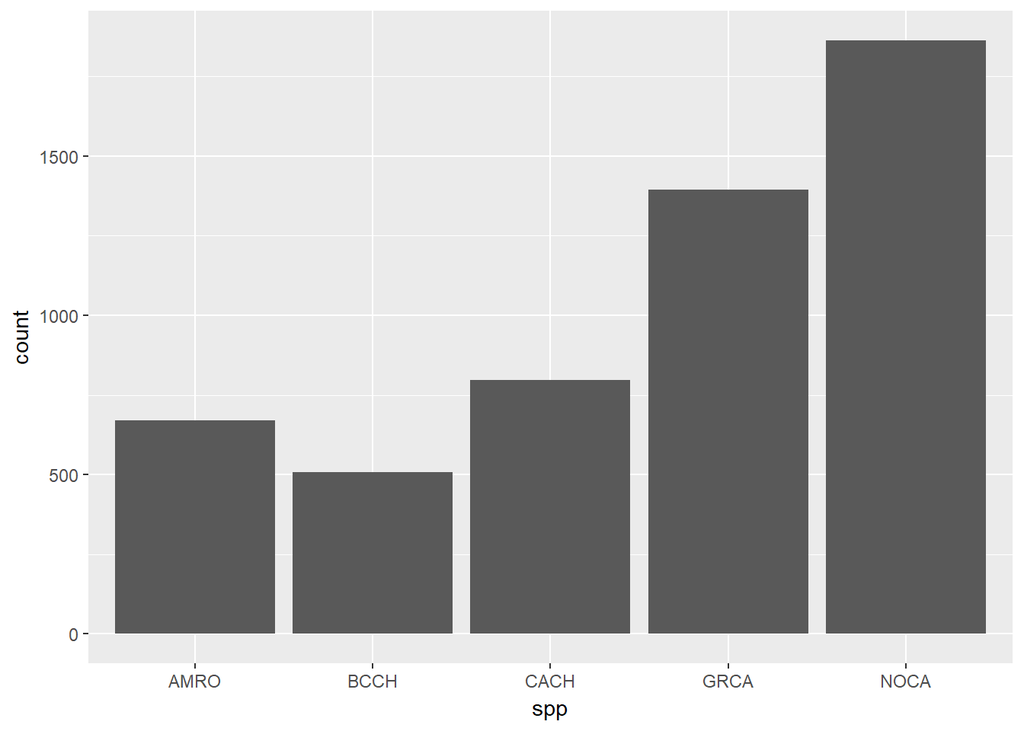

```r
birdMeasures %>%
  ggplot(aes(x = spp)) +
  geom_bar()
```

The above makes what is being plotted considerably clearer and allows us modify the data going in. For example, let’s remove the species “NOCA” (Northern cardinal) prior to plotting:

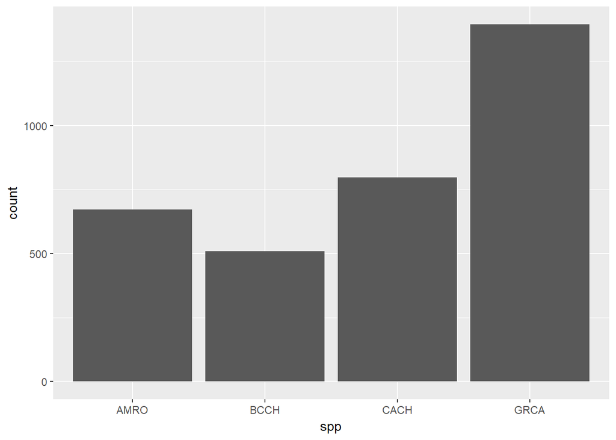

```r
birdMeasures %>%
  filter(spp != 'NOCA') %>%
  ggplot(aes(x = spp)) +
  geom_bar()
```

## Exercise One:

> The function `geom_density` can be used to display the density distribution of a vector. Using the **aesthetic** `x = mass`, display the distribution of Black-capped and Carolina chickadee mass measurements:

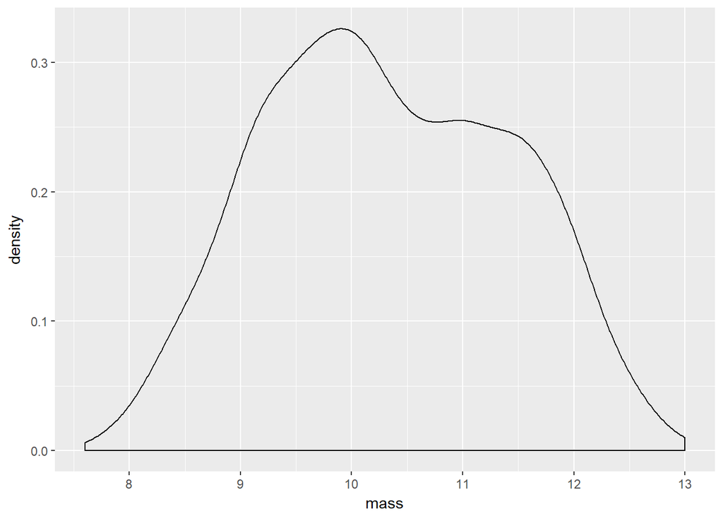

> ```r
> # Subset birdCounts to ground foraging birds:
>
> birdMeasures %>%
>   filter(spp %in% c('BCCH', 'CACH')) %>%
>   ggplot(aes(x = mass)) +
>   geom_density()
> ```

### Geometry: Adding arguments

The functions `geom_histogram` can be used to diplay distributional data as a histogram. The code below can be used to generate a histogram plot of the mass distribution of Black-capped and Carolina chickadees:

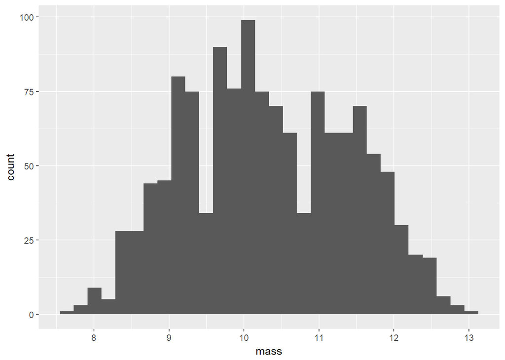

```r
# Subset birdCounts to ground foraging birds:

birdMeasures %>%
  filter(spp %in% c('BCCH', 'CACH')) %>%
  ggplot(aes(x = mass)) +
  geom_histogram()
```

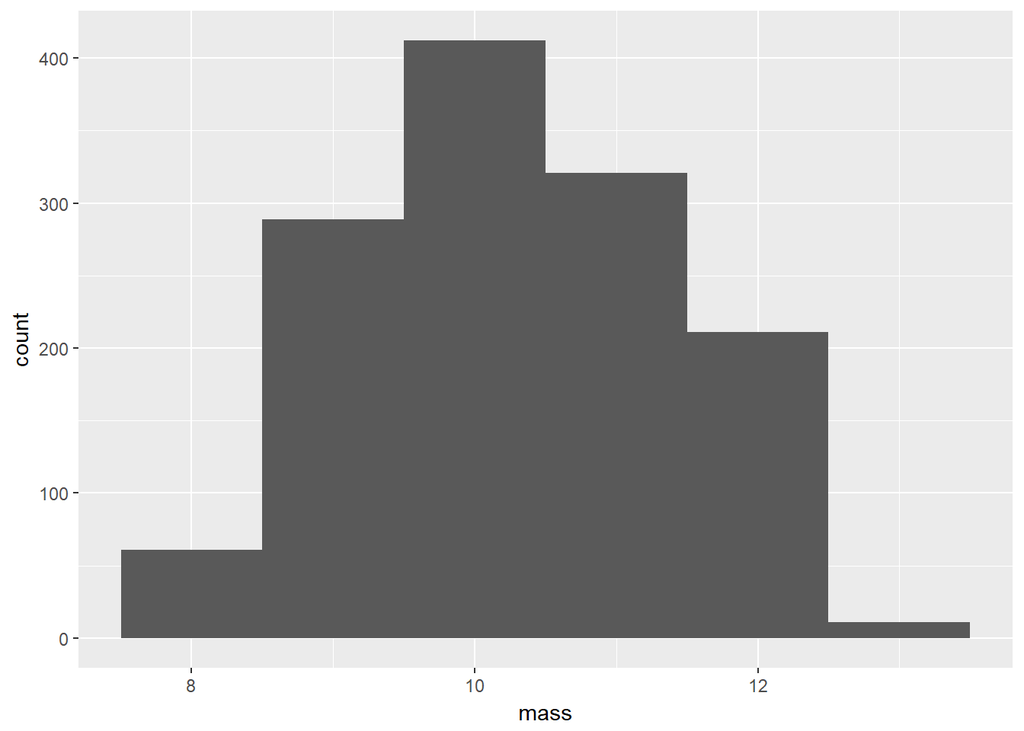

```r
# Subset birdCounts to ground foraging birds:

birdMeasures %>%
  filter(spp %in% c('BCCH', 'CACH')) %>%
  ggplot(aes(x = mass)) +
  geom_histogram(binwidth = 1)
```

You may also provide the number of bins, `bins`, to specify the number of bins to be drawn

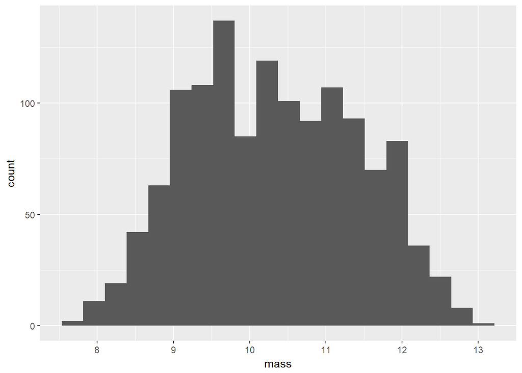

```r
# Subset birdCounts to ground foraging birds:

birdMeasures %>%
  filter(spp %in% c('BCCH', 'CACH')) %>%
  ggplot(aes(x = mass)) +
  geom_histogram(bins = 20)
```

Several features can be added to a geometry to improve the look of your plot. For example, let’s return to our bar plot of the number of birds captured per species and change the `fill` color of the bars to “gray”:

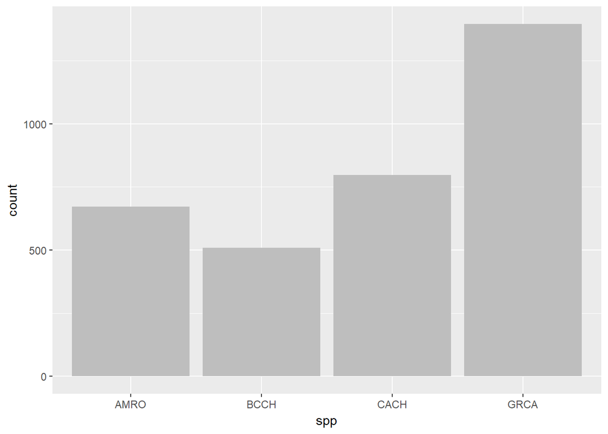

```r
# Subset birdCounts to ground foraging birds:

birdMeasures %>%
  filter(spp != 'NOCA') %>%
  ggplot(aes(x = spp)) +
  geom_bar(fill = 'gray')
```

Note that the argument is `fill` not `color` – `color` defines the outline of the bars:

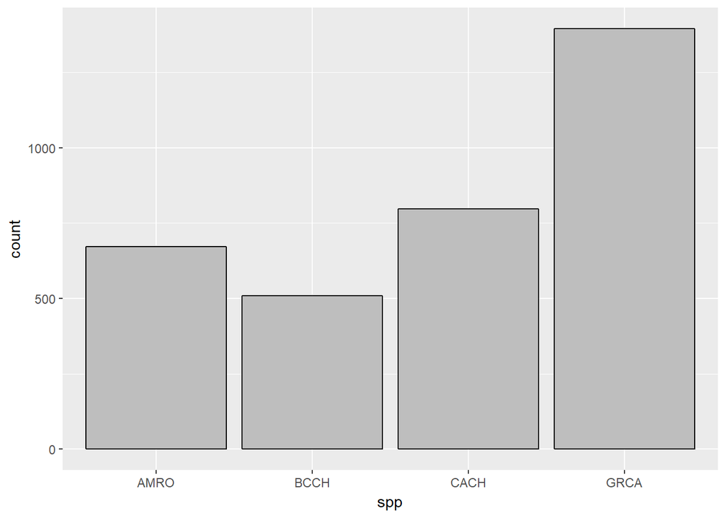

```r
# Subset birdCounts to ground foraging birds:

birdMeasures %>%
  filter(spp != 'NOCA') %>%
  ggplot(aes(x = spp)) +
  geom_bar(fill = 'gray',
           color = 'black')
```

We can adjust the size of the borders using the `size` argument of the `geom_bar` function:

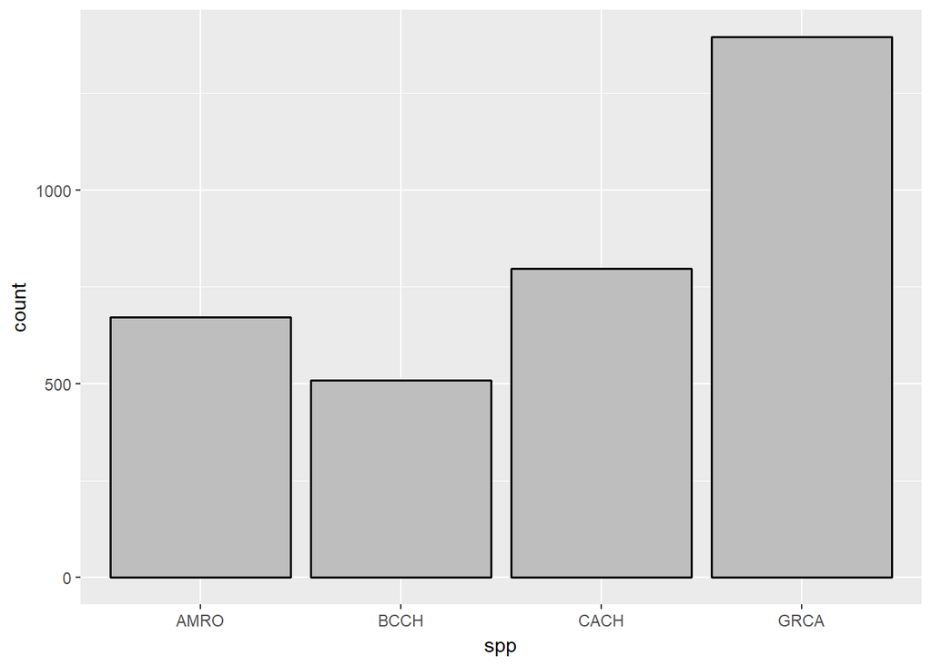

```r
# Subset birdCounts to ground foraging birds:

birdMeasures %>%
  filter(spp != 'NOCA') %>%
  ggplot(aes(x = spp)) +
  geom_bar(fill = 'gray',
           color = 'black',
           size = 0.7)
```

Note that it’s best practice in coding that each argument in a function (i.e. arguments separated by a comma) be written on its own line.

## Exercise Two:

> Modify your density plot from Exercise One:
> - Use the `fill` argument to fill your density shape with the color “gray”:
> - The argument `alpha` can be applied to a geometry to adjust its transparency. Adjust the density shape to `alpha = 0.7`

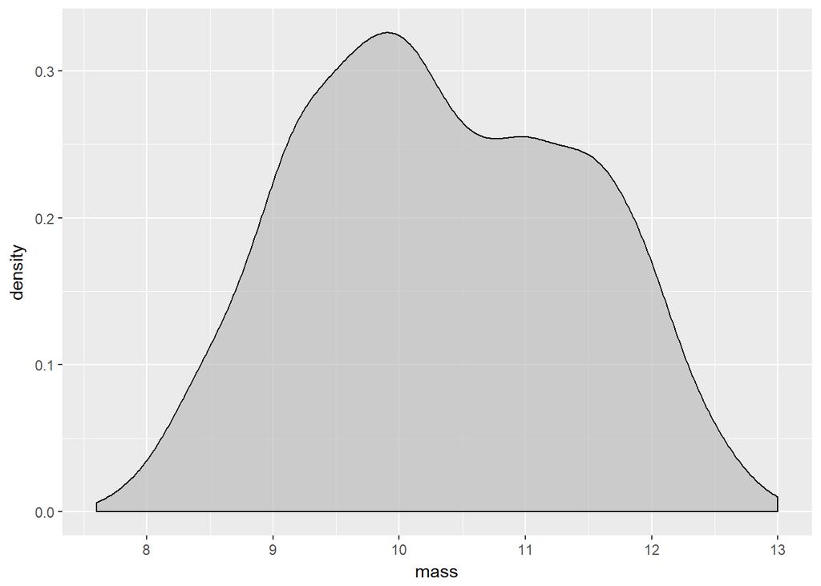

> ```r
> # Density, filled by species
> birdMeasures %>%
>   filter(spp %in% c('BCCH', 'CACH')) %>%
>   ggplot(aes(x = mass)) +
>   geom_density(fill = 'gray', alpha = 0.7)
> ```

### Geometry: Adding aesthetics

Additional **aesthetics** can be added to a geometry statement. Recall that aesthetics refer to mapping the value of some variable to an observable feature. For example, we may want to see the number of observations by region. To do so, let’s color the bars such that each region is represented by a color using the argument `fill`:

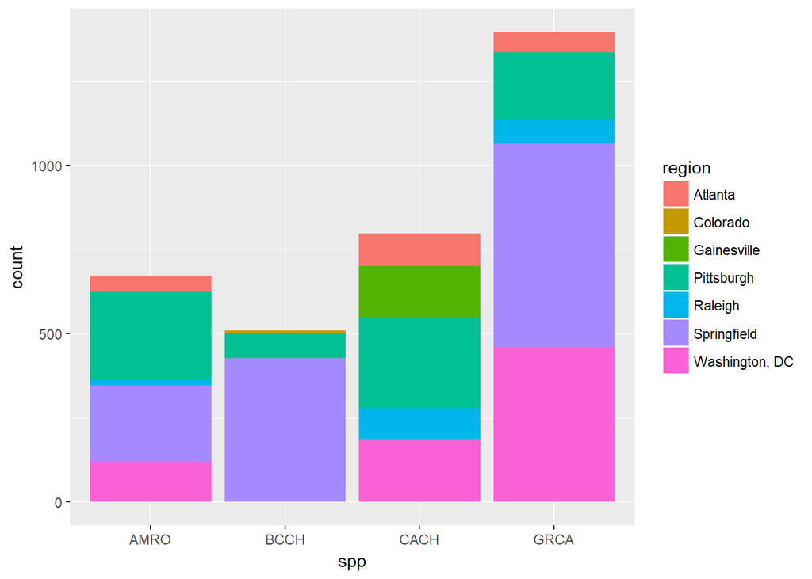

```r
birdMeasures %>%
  filter(spp != 'NOCA') %>%
  ggplot(aes(x = spp)) +
  geom_bar(aes(fill = region))
```

Let’s repeat the above with our histogram of chickadee mass measurements. We can add an aesthetics argument to the function `geom_histogram` to plot separate distributions for male and female chickadees:

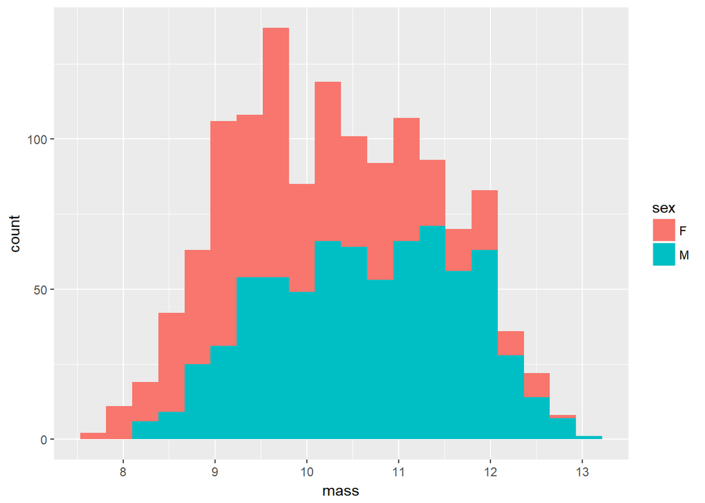

```r
# Density, filled by species
birdMeasures %>%
  filter(spp %in% c('BCCH', 'CACH')) %>%
  ggplot(aes(x = mass)) +
  geom_histogram(aes(fill = sex),
                 bins = 20)
```

Arguments that you might not want to map to a variable, such as `color`, are defined outside of the `aes` argument:

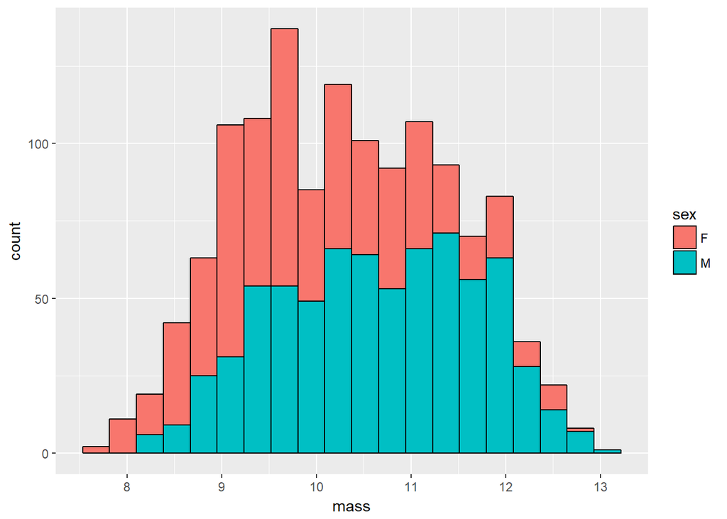

```r
birdMeasures %>%
  filter(spp %in% c('BCCH', 'CACH')) %>%
  ggplot(aes(x = mass)) +
  geom_histogram(aes(fill = sex),
                 bins = 20,
                 color = 'black')
```

## Exercise Three:

> Modify your density plot from Exercise Two. Use the `fill` argument of the function `geom_density` to assign a different fill color to females and males.

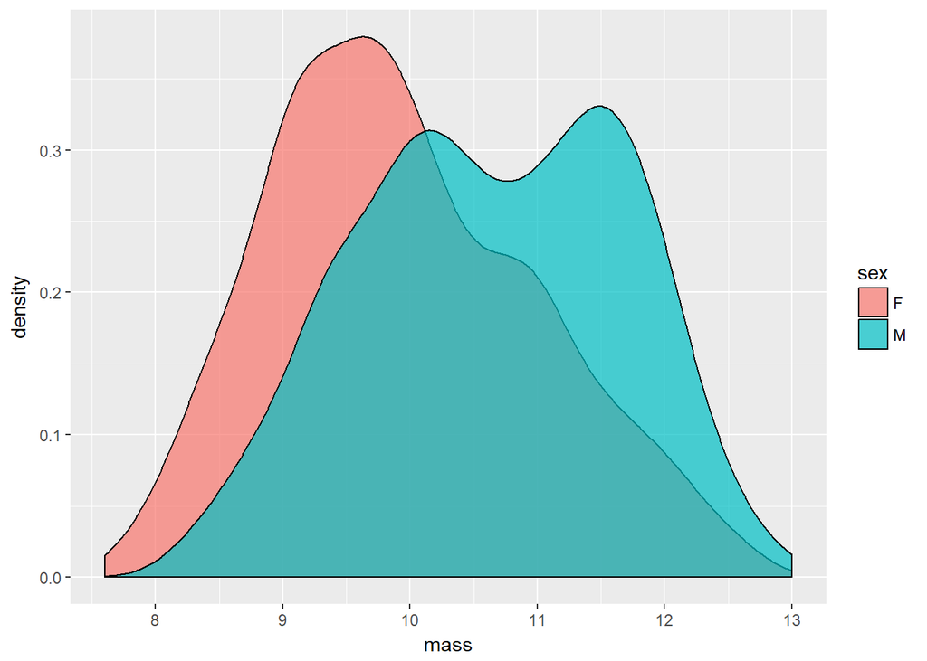

> ```r
> # Density plot, filled by sex:
>
> birdMeasures %>%
>   filter(spp %in% c('BCCH', 'CACH')) %>%
>   ggplot(aes(x = mass)) +
>   geom_density(aes(fill = sex),
>                alpha = 0.7)
> ```

## Facets

Facets allow you to display multiple plots, which can be very useful to show differences between groups. Let’s use the `facet_wrap` function and your histogram to compare differences in mass between Black-capped and Carolina chickadees.

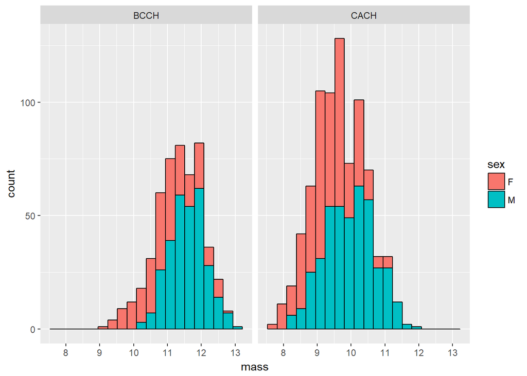

```r
birdMeasures %>%
  filter(spp %in% c('BCCH', 'CACH')) %>%
  ggplot(aes(x = mass)) +
  geom_histogram(aes(fill = sex),
                 bins = 20,
                 color = 'black') +
  facet_wrap(~spp)
```

By separating Black-capped and Carolina chickadees, the difference between mass measurements is apparent. Your eyes still have to do too much work to compare them though. We can use the `nrow` argument of the `facet_wrap` function to move the plots on top of one another:

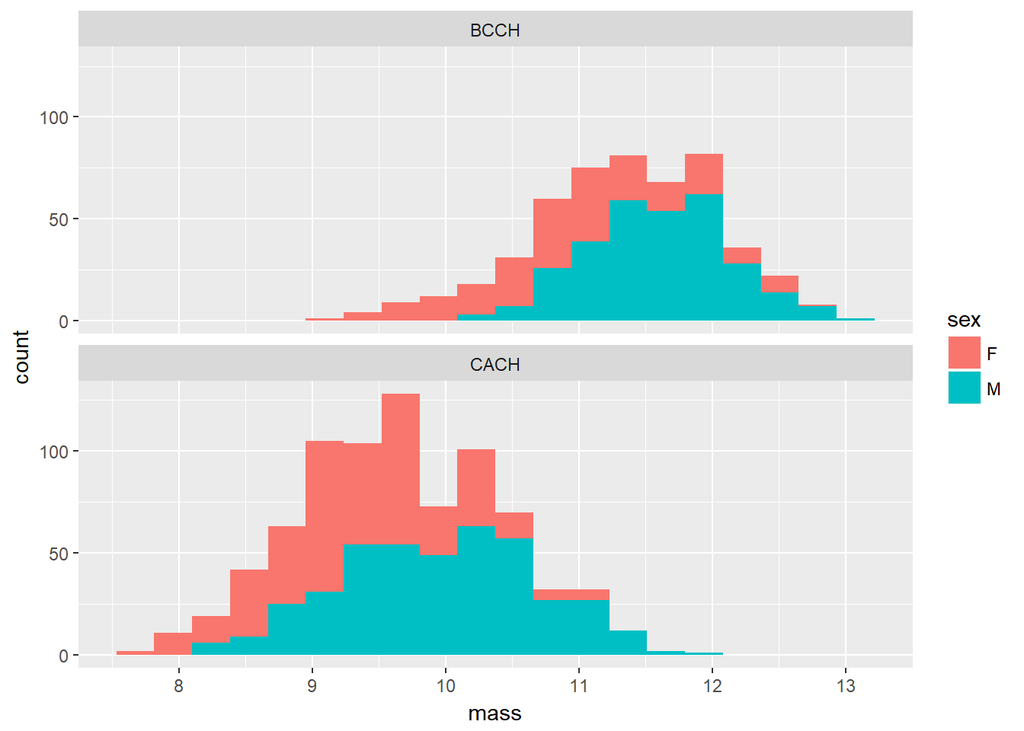

```r
birdMeasures %>%
  filter(spp %in% c('BCCH', 'CACH')) %>%
  ggplot(aes(x = mass)) +
  geom_histogram(aes(fill = sex), bins = 20) +
  facet_wrap(~spp, nrow = 2)
```

## Exercise Four:

> Modify your density plot from Exercise Three. Use the `facet_wrap` function with the argument `nrow = 2` to generate separate plots of Black-capped and Carolina chickadees.

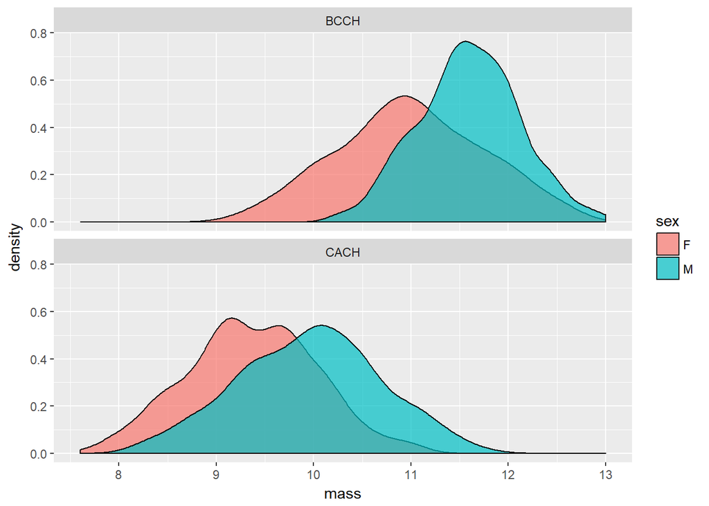

> ```r
> # Density plot, filled by sex:
>
> birdMeasures %>%
>   filter(spp %in% c('BCCH', 'CACH')) %>%
>   ggplot(aes(x = mass)) +
>   geom_density(aes(fill = sex),
>                alpha = 0.7) +
>   facet_wrap(~spp, nrow = 2)
> ```

## Labels

Even the best-looking plot can be marred by using unattractive titles. Let’s modify the bar plot of captures by species and region above. To change the axis titles and add a title to the plot, we can use the `labs` function:

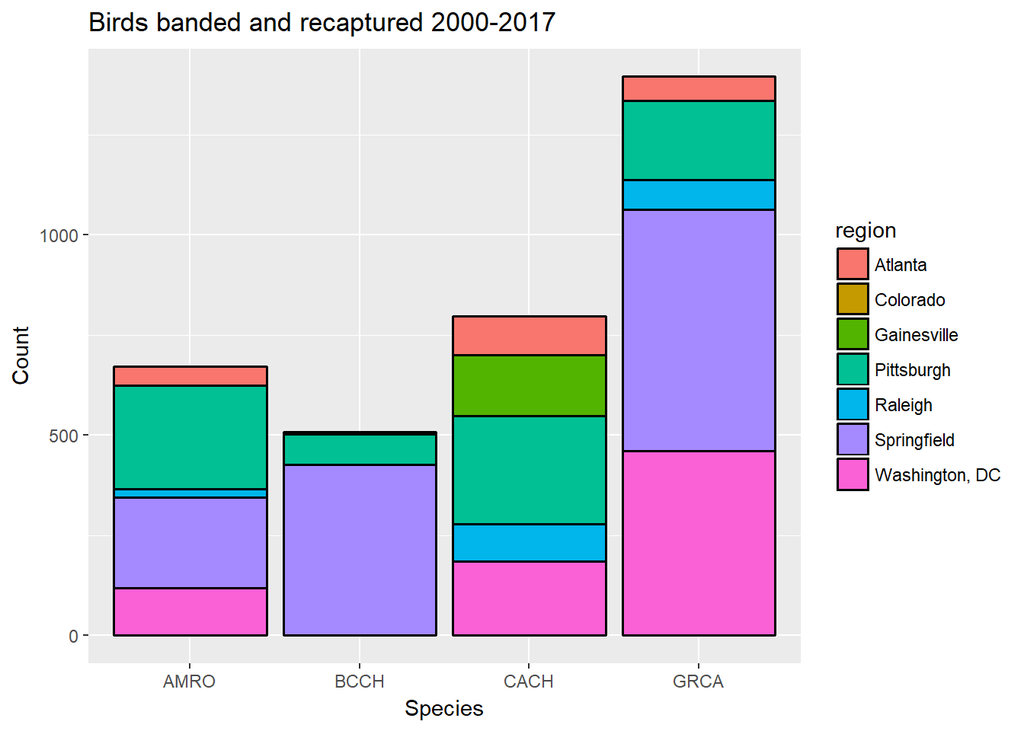

```r
birdMeasures %>%
  filter(spp != 'NOCA') %>%
  ggplot(aes(x = spp)) +
  geom_bar(aes(fill = region),
           color = 'black',
           size = .7) +
  labs(title = 'Birds banded and recaptured 2000-2017',
       x = 'Species',
       y = 'Count')
```

Piping can be useful for changing labels. For example, not many people outside of ornithology know the four-letter alpha code for birds. We can map the codes to species names using the `labels` argument of the `factor` function (from lesson one):

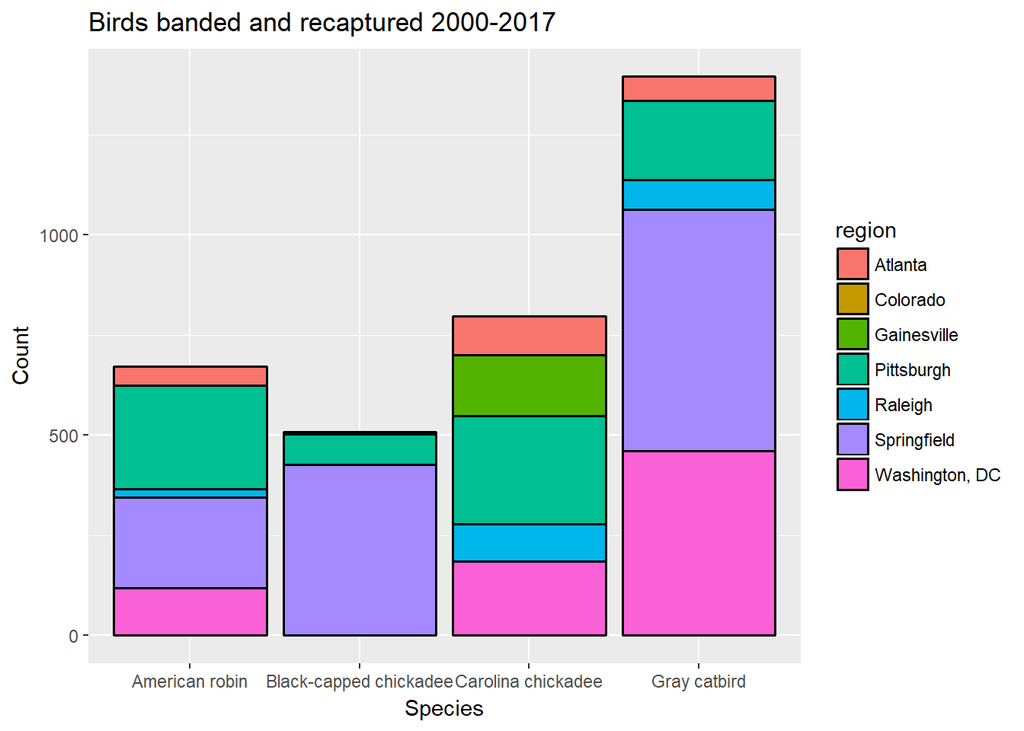

```r
birdMeasures %>%
  filter(spp != 'NOCA') %>%
  mutate(spp = factor(
    spp,
    labels = c(
      'American robin',
      'Black-capped chickadee',
      'Carolina chickadee',
      'Gray catbird'
    )
  )) %>%
  ggplot(aes(x = spp)) +
   geom_bar(aes(fill = region),
           color = 'black',
           size = .7) +
  labs(title = 'Birds banded and recaptured 2000-2017',
       x = 'Species',
       y = 'Count')
```

You may have noticed that `ggplot` code can get unwieldly because of all of the arguments. Once you are happy with the basic elements of your plot (data in, plot aesthetics, and geometry), it’s a good idea to assign a name to the plot.

```r
birdCaptures_basicPlot <- birdMeasures %>%
  filter(spp != 'NOCA') %>%
  mutate(spp = factor(
    spp,
    labels = c(
      'American robin',
      'Black-capped chickadee',
      'Carolina chickadee',
      'Gray catbird'
    )
  )) %>%
  ggplot(aes(x = spp)) +
   geom_bar(aes(fill = region),
           color = 'black',
           size = .7) +
  labs(title = 'Birds banded and recaptured 2000-2017',
       x = 'Species',
       y = 'Count')
```

You can then call the plot by simply typing its name:

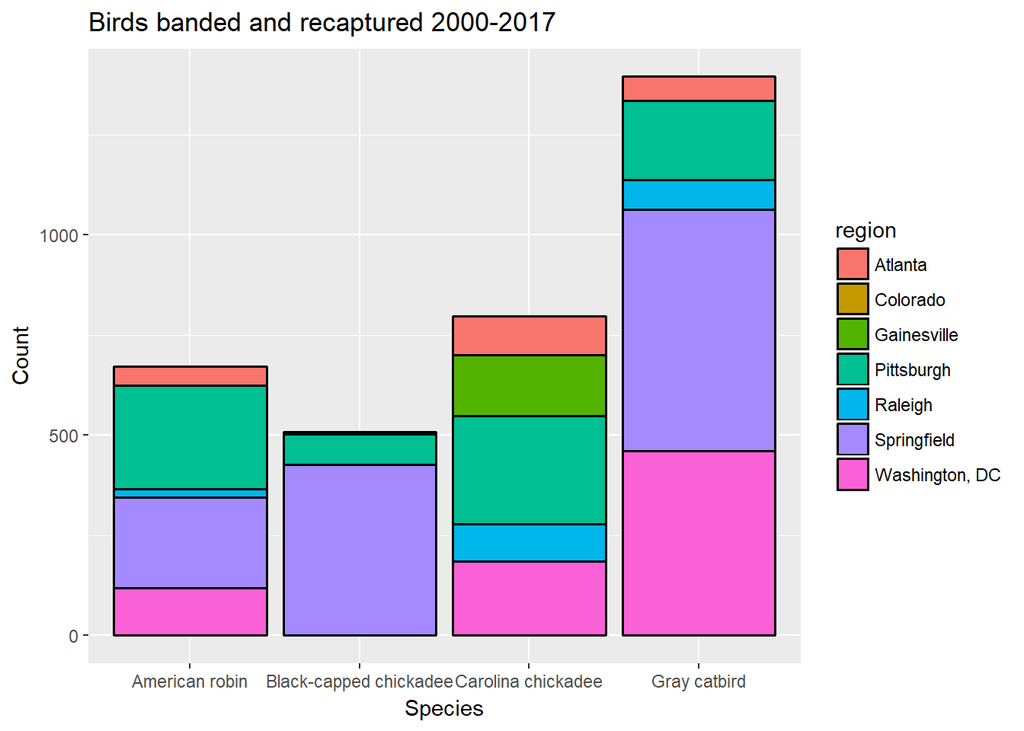

```r
birdCaptures_basicPlot
```

## Exercise Five:

> Modify the density plot you created in Exercise Four:
> - Using the piping method, change the names “BCCH” and “CACH” to “Black-capped” and “Carolina”
> - Add the title “Mass of Carolina and Black-capped chickadees and capitalize the x and y axis titles
> - Assign the name “massDensity” to the plot

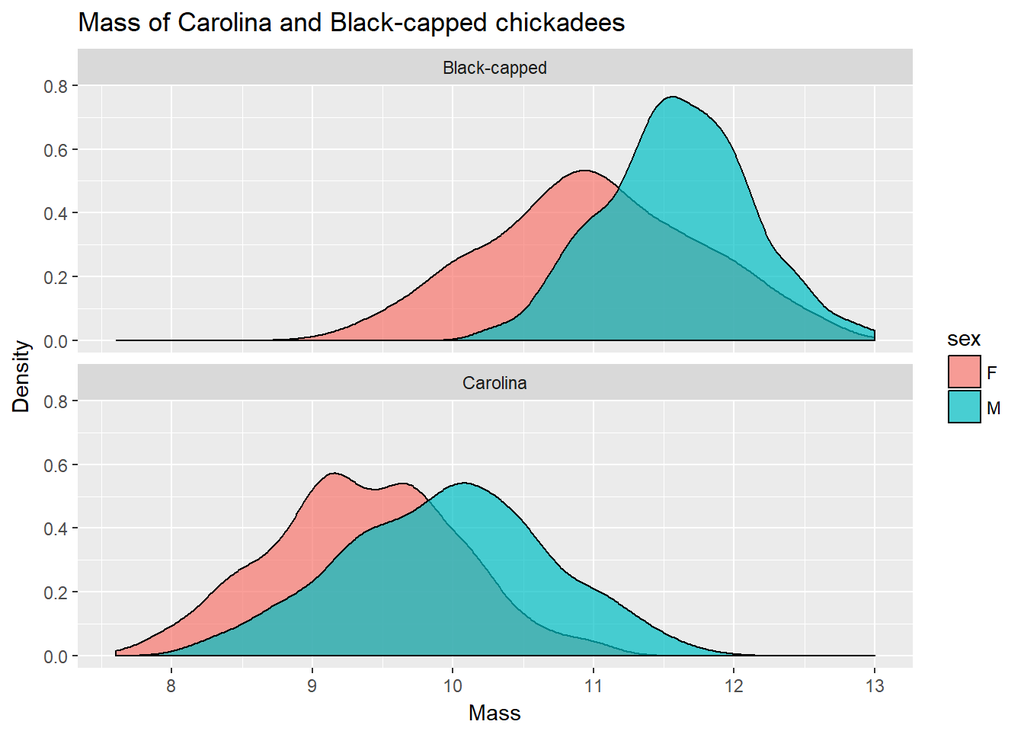

> ```r
> # Labels for massDensity:
>
> massDensity <- birdMeasures %>%
>   filter(spp %in% c('BCCH', 'CACH')) %>%
>   mutate(spp = factor(
>     spp,
>     labels = c(
>       'Black-capped',
>       'Carolina'
>     )
>   )) %>%
>   ggplot(aes(x = mass)) +
>   geom_density(aes(fill = sex),
>                alpha = 0.7) +
>   facet_wrap(~spp, nrow = 2) +
>   labs(title = "Mass of Carolina and Black-capped chickadees",
>        x = 'Mass',
>        y = 'Density')
>
> massDensity
> ```

## Scaling axes

The default choice of scale for the axes are typically not very professional looking. Let’s rescale our y axis. By default, there is additional space at the bottom and top of the axis. This is known as **axis expansion**. We can remove this using the function `scale_y_continuous` with the argument `expand`:

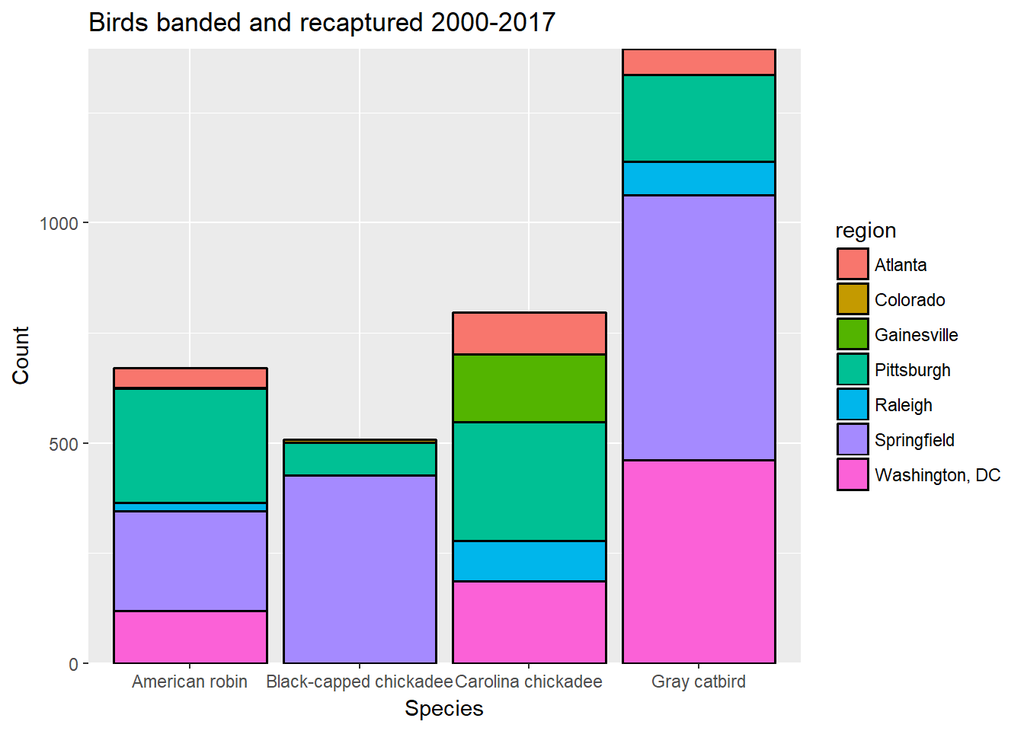

```r
birdCaptures_basicPlot +
  scale_y_continuous(expand = c(0,0))
```

The vector `c(0,0)` above removes the default expansion between the limits of values and the ends of the axes.

The above is still not very aesthetically pleasing, because we’ve run out of y-axis labels (tick marks) above 1000 and the Gray catbird bar touches the top of the plot. We can use `scale_y_continuous` to manually set the beginning and end points of the y axis. To determine the appropriate point, let’s first take a look at the values we will be plotting:

```r
birdMeasures %>%
  filter(spp != 'NOCA') %>%
  group_by(spp) %>%
  summarize(n = n())
```

```
## # A tibble: 4 x 2
##     spp     n
##   <chr> <int>
## 1  AMRO   671
## 2  BCCH   508
## 3  CACH   797
## 4  GRCA  1395
```

We can see in the above that the count of Gray catbirds is 1395. A y-axis that spans from 0 to 1500 would probably be appropriate. We can use the `limits` argument with a vector representing the bottom and top value (`c([bottom], [top])`) to manually set the axis limits:

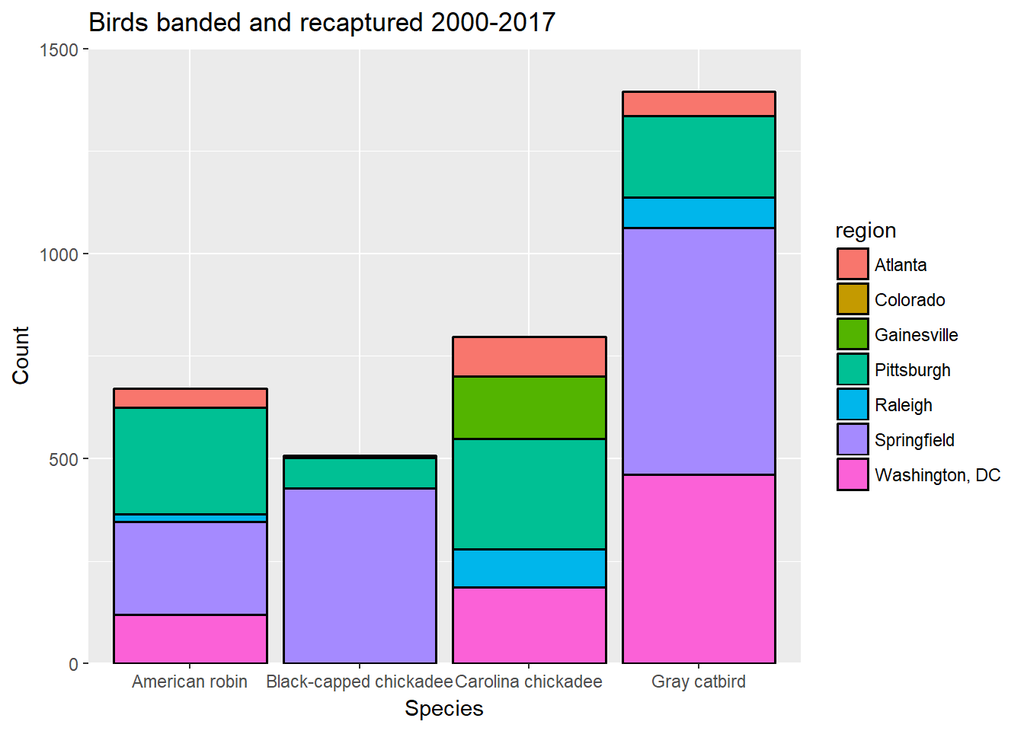

```r
birdCaptures_basicPlot +
  scale_y_continuous(expand = c(0, 0),
                     limits = c(0, 1500))
```

We can also manually set the breaks (tick marks) between the limits. For example, perhaps we want tick marks on the y-axis every 250 birds. We use the `breaks` argument of the `scale_y_continuous` function:

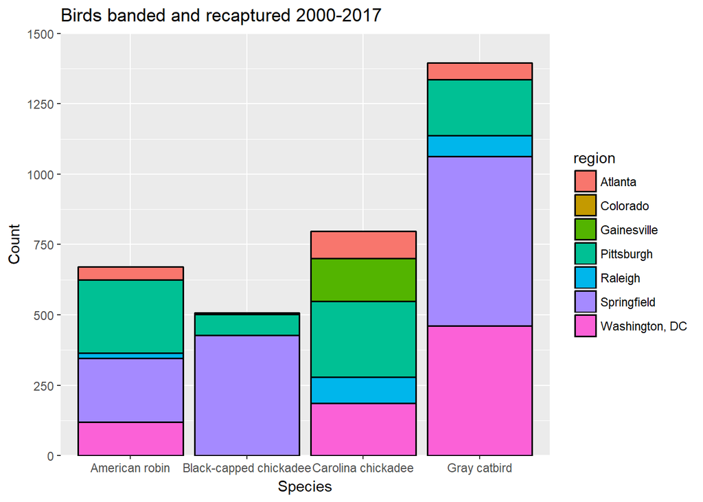

```r
birdCaptures_basicPlot +
  scale_y_continuous(expand = c(0, 0),
                     limits = c(0, 1500),
                     breaks = seq(0, 1500, by = 250))
```

## Exercise Six:

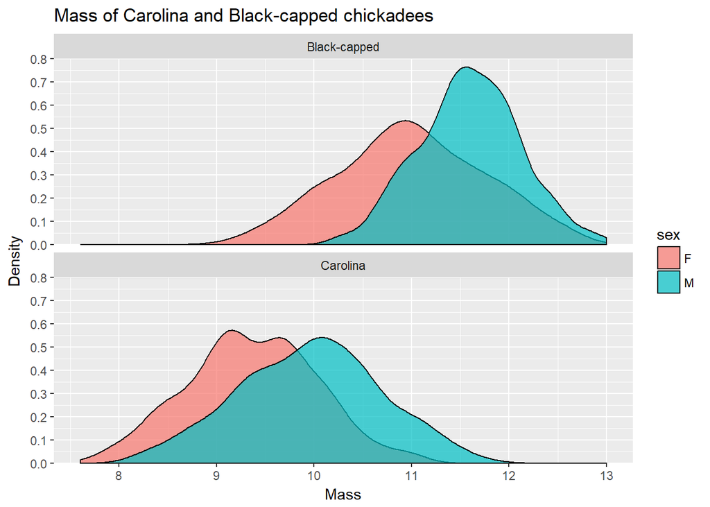

> ```r
> # new y axis scale for massDensity:
>
> massDensity +
>   scale_y_continuous(expand = c(0, 0),
>                      limits = c(0, 0.8),
>                      breaks = seq(0, 0.8, by = 0.1))
> ```

## Colors

The default colors that ggplot uses are just plain ugly. Luckily it’s easy to modify the colors to those of your choosing. Here we’ll use the function `scale_fill_manual` to specify the colors for the fill:

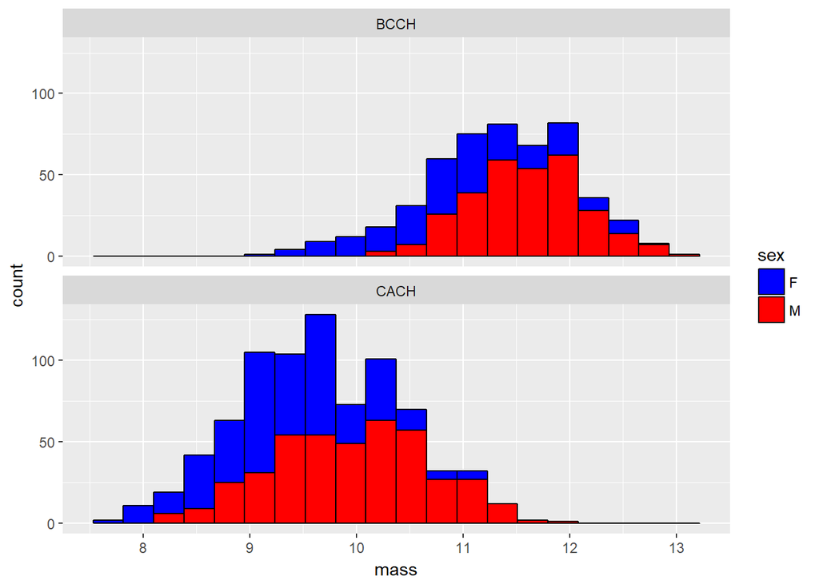

```r
birdMeasures %>%
  filter(spp %in% c('BCCH', 'CACH')) %>%
  ggplot(aes(x = mass)) +
  geom_histogram(aes(fill = sex),
                 bins = 20,
                 color = 'black') +
  facet_wrap(~spp, nrow = 2) +
  scale_fill_manual(values = c('blue', 'red'))
```

There really wasn’t much improvement here. My preference is to hunt around for colors I like and grab their hex codes. For example, I used a “color-picker” app to extract the colors of Team Zissou’s uniforms from the movie The Life Aquatic.

[figure not shown]

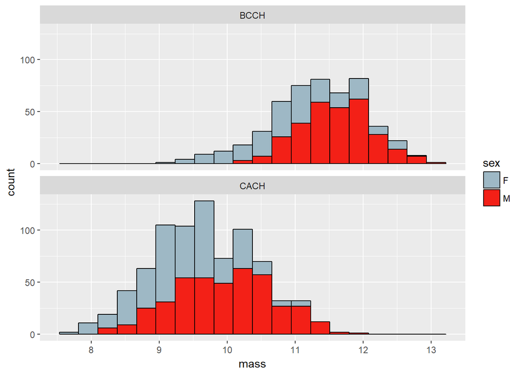

```r
birdMeasures %>%
  filter(spp %in% c('BCCH', 'CACH')) %>%
  ggplot(aes(x = mass)) +
  geom_histogram(aes(fill = sex),
                 bins = 20,
                 color = 'black') +
  facet_wrap(~spp, nrow = 2) +
  scale_fill_manual(values = c('#9EB8C5', '#F32017'))
```

It’s a good idea to save the colors that you like for future use. For example, I could have have saved my colors as:

```
zPalette <- c(shirt = '#9EB8C5', hat = '#F32017')
```

You can then apply your custom color palette using:

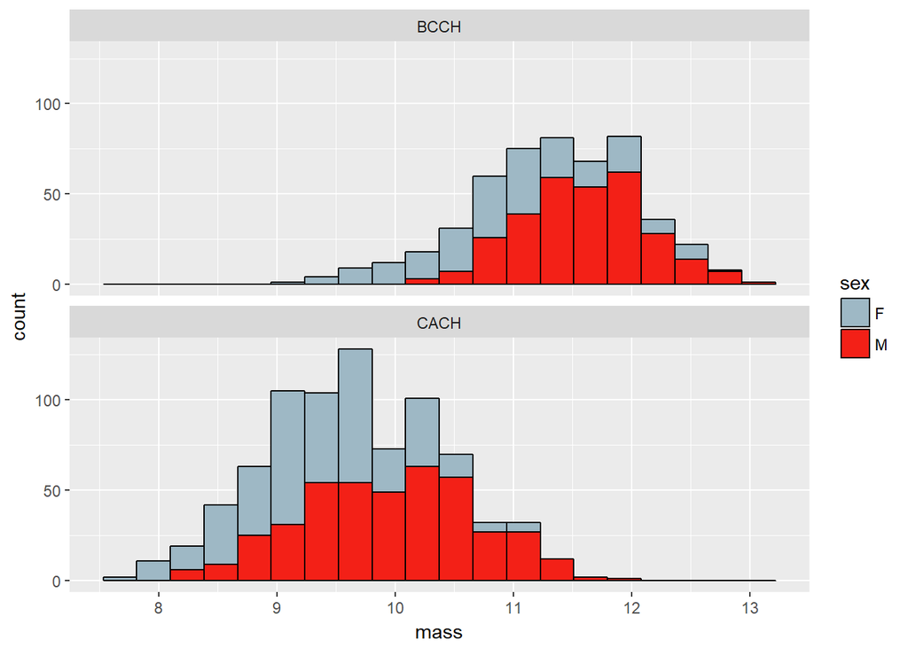

```r
birdMeasures %>%
  filter(spp %in% c('BCCH', 'CACH')) %>%
  ggplot(aes(x = mass)) +
  geom_histogram(aes(fill = sex),
                 bins = 20,
                 color = 'black') +
  facet_wrap(~spp, nrow = 2) +
  scale_fill_manual(values = zPalette)
```